# VISTA Activities 2012-16

## About

*Document version: May 15, 2019*

This document describes the process for calculating the spread of activities of Melbournians by time of day. The Victorian Integrated Survey of Travel & Activity (VISTA) 2012-16 data is used for this purpose.

## Data

## Sourcing VISTA 2012-16 Data

The Victorian Integrated Survey of Travel & Activity (VISTA) 2012-16 data was downloaded from the following URL on 10th May 2019:

```
https://transport.vic.gov.au/-/media/tfv-documents/vista/vista_2012_16_v1_sa1_csv.zip
```

The Zip archive was uncompressed, and the contained CSV files recompressed using GZip giving:

```
./VISTA_2012_16_v1_SA1_CSV/JTW_VISTA12_16_SA1_V1.csv.gz
./VISTA_2012_16_v1_SA1_CSV/S_VISTA12_16_SA1_V1.csv.gz
./VISTA_2012_16_v1_SA1_CSV/H_VISTA12_16_SA1_V1.csv.gz
./VISTA_2012_16_v1_SA1_CSV/P_VISTA12_16_SA1_V1.csv.gz
./VISTA_2012_16_v1_SA1_CSV/JTE_VISTA12_16_sa1_V1.csv.gz
./VISTA_2012_16_v1_SA1_CSV/T_VISTA12_16_SA1_V1.csv.gz
```

## Understanding Trip Data

We use Trip Table (`T_VISTA12_16_SA1_V1.csv`) with these select columns:

```
---------------------------------------------------------------------------
Column            Description
----------------  ---------------------------------------------------------
PERSID            Person ID number
TRAVDOW           Travel day day-of-week
ORIGPURP1         Origin Purpose (Summary)
DESTPURP1         Destination Purpose (Summary)
STARTIME          Time of Starting Trip Stage (in minutes, from midnight)
ARRTIME           Time of Ending Trip Stage (in minutes, from midnight)
CW_WDTRIPWGT_LGA  Trip weight for an 'Average weekday’ of the combined
                  2012-14 and 2014-16 ReportingPeriods, using the ASGC.
CW_WETRIPWGT_LGA  Trip weight for an 'Average weekend day' of the combined
                  2012-14 and 2014-16 ReportingPeriods, using the ASGC.
---------------------------------------------------------------------------
```

## Example Trip Record for a Person

```
--------------------------------------------------------------------------------------------
        PERSID TRAVDOW         ORIGPURP1         DESTPURP1 STARTIME ARRTIME CW_WDTRIPWGT_LGA
-------------- ------- ----------------- ----------------- -------- ------- ----------------
Y12H0000126P01  Friday     At or Go Home      Work Related      475     535           139.78
Y12H0000126P01  Friday      Work Related Personal Business      580     590           139.78
Y12H0000126P01  Friday Personal Business      Work Related      600     610           139.78
Y12H0000126P01  Friday      Work Related     At or Go Home     1050    1125           139.78
--------------------------------------------------------------------------------------------
```

## Extracting Activities from Trip Records

We convert every person’s trip record:

```
--------------------------------------------------------------------------------------------
        PERSID TRAVDOW         ORIGPURP1         DESTPURP1 STARTIME ARRTIME CW_WDTRIPWGT_LGA
-------------- ------- ----------------- ----------------- -------- ------- ----------------
Y12H0000126P01  Friday     At or Go Home      Work Related      475     535           139.78
Y12H0000126P01  Friday      Work Related Personal Business      580     590           139.78
Y12H0000126P01  Friday Personal Business      Work Related      600     610           139.78
Y12H0000126P01  Friday      Work Related     At or Go Home     1050    1125           139.78
--------------------------------------------------------------------------------------------
```

To that person’s activity record like this:

```
--------------------------------------------------------------------------------------
        PERSID TRAVDOW          ACTIVITY  ACT.START.TIME ACT.END.TIME CW_WDTRIPWGT_LGA
-------------- ---------------- --------- -------------- ------------ ----------------
Y12H0000126P01  Friday     At or Go Home               0          475           139.78
Y12H0000126P01  Friday      Work Related             535          580           139.78
Y12H0000126P01  Friday Personal Business             590          600           139.78
Y12H0000126P01  Friday      Work Related             610         1050           139.78
Y12H0000126P01  Friday     At or Go Home            1125         1439           139.78
--------------------------------------------------------------------------------------
```

## Simplifying Activity Labels

1. Remove `Change Mode` activitiy which is an in-transit mode-change event.
2. Remove `Accompany Someone` activity which is a secondary activitiy.
3. Group the remaining activities into activity groups as follows:

   ```
   ----------------------------------------------------------------------------------------
   Activities                                                       Activity Group
   ---------------------------------------------------------------- -----------------------
   At or Go Home                                                    Home
   Unknown purpose (at start of day), Other Purpose, Not Stated     Other
   Personal Business                                                Personal
   Work Related                                                     Work
   Education                                                        Study
   Buy Something                                                    Shop
   Social Recreational                                              Social/Recreational
   Pick-up or Drop-off Someone, Pick-up or Deliver Something        Pickup/Dropoff/Deliver
   ----------------------------------------------------------------------------------------
   ```

## Creating Activity Bins by Time of Day

1. Cut the day into fixed time bins of configurable size (30/60/120 mins)
2. For every activity record, count `CW_WDTRIPWGT_LGA` persons in every time bin that overlaps with the activity time
3. For any time bins that do not add up to the expected population (sum of `CW_WDTRIPWGT_LGA` per unique person), scale up the time bin vector of activities to the expected population size, proportionally.

   ```
   dd<-aggregate(activities,by=list(activities$Person),FUN=head,n=1)
   popnsize<-sum(dd$Count)
   actCounts<-t(apply(actCounts,1, function(x, mx) {(x/sum(x))*mx}, mx=popnsize))
   ```

## Outputs

## Weekday activities for Greater Melbourne

### 30 min bins

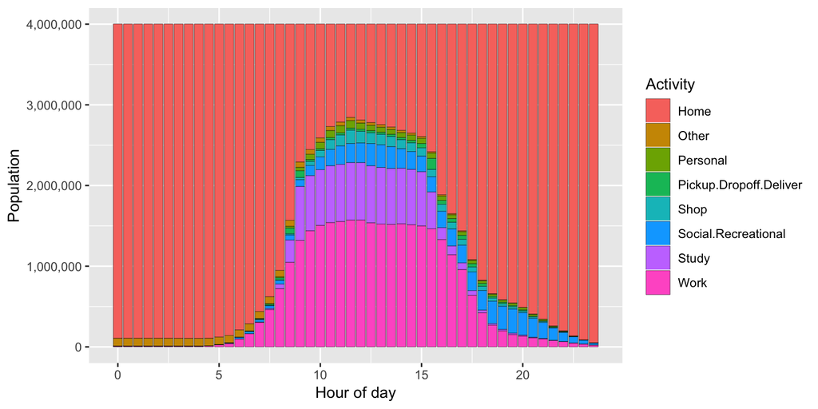

## Weekday activities for Greater Melbourne

### 60 min bins

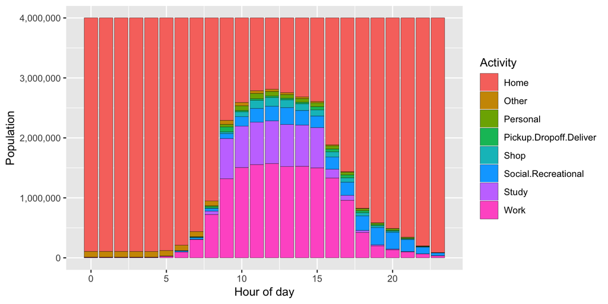

## Weekday activities for Greater Melbourne

### 120 min bins

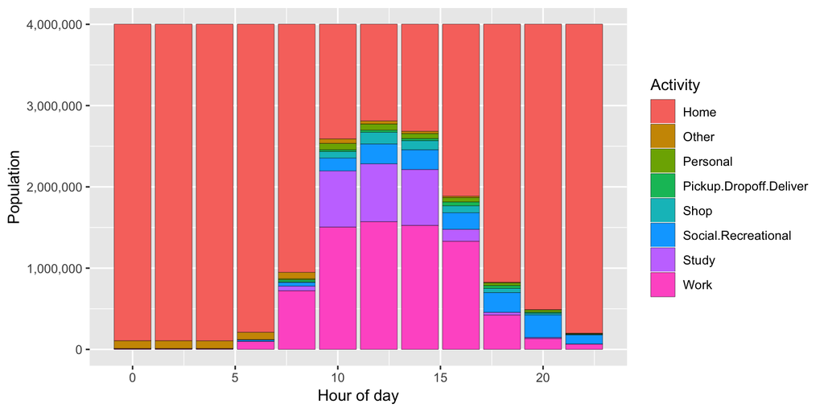

## Weekend activities for Greater Melbourne

### 30 min bins

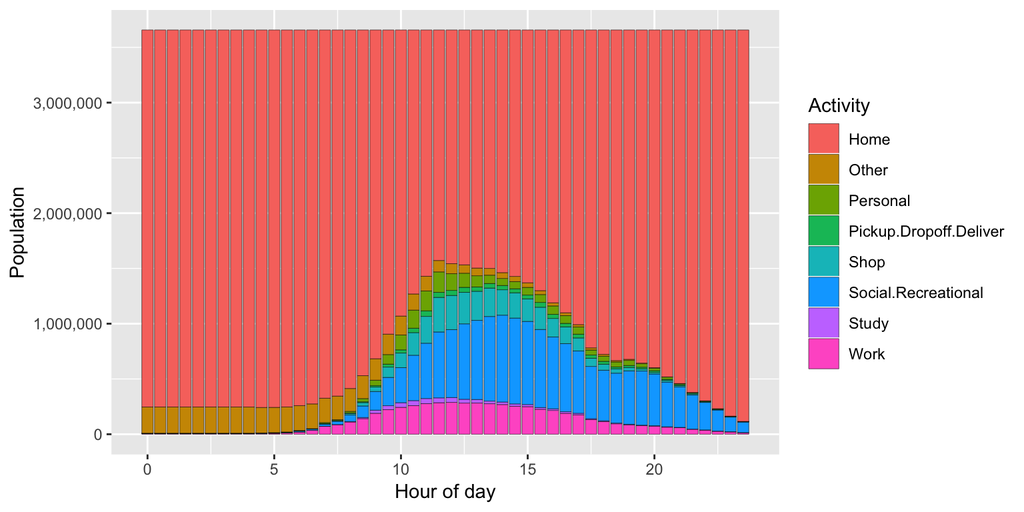

## Weekend activities for Greater Melbourne

### 60 min bins

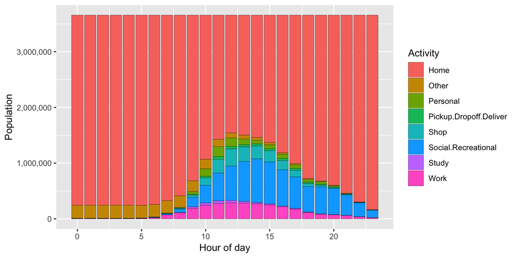

## Weekend activities for Greater Melbourne

### 120 min bins

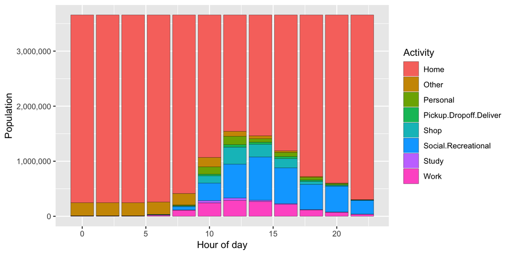